Understanding the Dataset

The dataset "Top Rich 2024" explores the wealth distribution among the world's billionaires. It includes rankings, net worth, and regional affiliations of 500 individuals, providing insights into economic trends and the dominance of specific industries.

Information taken from (https://kaggle/datasets )

# Step by step to Perform Data Analysis:

1. Importing the dataset into DataFrame:

The very first task is to import the required libraries. In this case, we need Pandas and Matplotlib, so you can see in the following coding snippet that we imported these libraries:

```python
import pandas as pd
import matplotlib.pyplot as plt
import seaborn as sns

df = pd.read_csv("/workspaces/codespaces-jupyter/data/toprich2024.csv")
print(df.describe())
```

```
             Rank
count  500.000000
mean   250.500000
std    144.481833
min      1.000000
25%    125.750000
50%    250.500000
75%    375.250000
max    500.000000
```

Let’s begin by cleaning the dataset and converting financial data into numeric formats.

# Load the newly uploaded dataset into a DataFrame for inspection

2. Cleaning and Preparing The Data:

   a. Notice the columns:

   ```
   We can use the df.columns = df.columns.str.strip()  to get all columns from the dataframe data
   ```

```python
df.columns = df.columns.str.strip()
print(df.columns)
```

```
Index(['Rank', 'Name', 'Total net worth', '$ Last change', '$ YTD change',
       'Country / Region', 'Industry'],
      dtype='object')
```

b. Define the clean_currency function

```
  We need to transform monetary values stored as strings into numerical values to enable accurate calculations. (billions)
        Checks whether the value contains the "B" suffix, which indicates billions. Same with millions using elif statement.
```

```python
def clean_currency(value):
    value = value.strip()
    if 'B' in value:
        return float(value.replace('$', '').replace('B', '').replace(',', ''))
    elif 'M' in value:
        return float(value.replace('$', '').replace('M', '').replace(',', '')) / 1000
    else:
        return float(value.replace('$', '').replace(',', ''))
```

e. Apply the clean_currency function

```
To transform the Total net worth column into numeric values, we apply the clean_currency function to each entry.
```

```python
df['Total net worth'] = df['Total net worth'].apply(clean_currency)
```

f. Verify the Transformation

After applying the function, verify that the column is correctly transformed.

```python
print(df['Total net worth'].head())

print(df['Total net worth'].dtype)
```

```
0    447.0
1    249.0
2    224.0
3    198.0
4    181.0
Name: Total net worth, dtype: float64
float64
```

g. Ensure the Required Columns Exist

For calculating the 5-year average, ensure that the base columns (e.g., '2019_net_worth', '2021_net_worth', etc.) are in the DataFrame. Run this:

```python
# Check the required columns for averaging
required_columns = ['2019_net_worth', '2021_net_worth', '2022_net_worth', '2023_net_worth', '2024_net_worth']
missing_columns = [col for col in required_columns if col not in df.columns]
print(f"Missing columns: {missing_columns}")
for col in required_columns:
    if col not in df.columns:
        df[col] = 0  # Replace 0 with an appropriate placeholder if needed
```

```
Missing columns: ['2019_net_worth', '2021_net_worth', '2022_net_worth', '2023_net_worth', '2024_net_worth']
```

Step 1: Recalculate '5yrs_avg_net_worth'

First, ensure that the calculation is correctly implemented. We'll compute the 5-year average net worth using the columns

```python
# Fill missing values with realistic default values, like a placeholder or an average
df[['2019_net_worth', '2021_net_worth', '2022_net_worth', '2023_net_worth', '2024_net_worth']] = \
    df[['2019_net_worth', '2021_net_worth', '2022_net_worth', '2023_net_worth', '2024_net_worth']].fillna(0)
```

```python
df['5yrs_avg_net_worth'] = df[['2019_net_worth', '2021_net_worth', '2022_net_worth', '2023_net_worth', '2024_net_worth']].mean(axis=1)

# Verify the output
print(df[['Name', '5yrs_avg_net_worth']].head())
```

```
              Name  5yrs_avg_net_worth
0        Elon Musk                 0.0
1       Jeff Bezos                 0.0
2  Mark Zuckerberg                 0.0
3    Larry Ellison                 0.0
4  Bernard Arnault                 0.0
```

# Analyze and Visualize Data

Now that the data is cleaned, let's perform various analyses and visualizations.

1. Distribution of Net Worth by Industry Visualize the total net worth across different industries using a bar plot.

   ```
    The sns.barplot() function creates a bar plot using Seaborn. It uses a DataFrame df, with the x-axis representing the Industry and the y-axis showing the Total net worth. The confidence intervals are removed for simplicity (ci=None), and the sum of the Total net worth is calculated for each industry using estimator=sum.
   ```

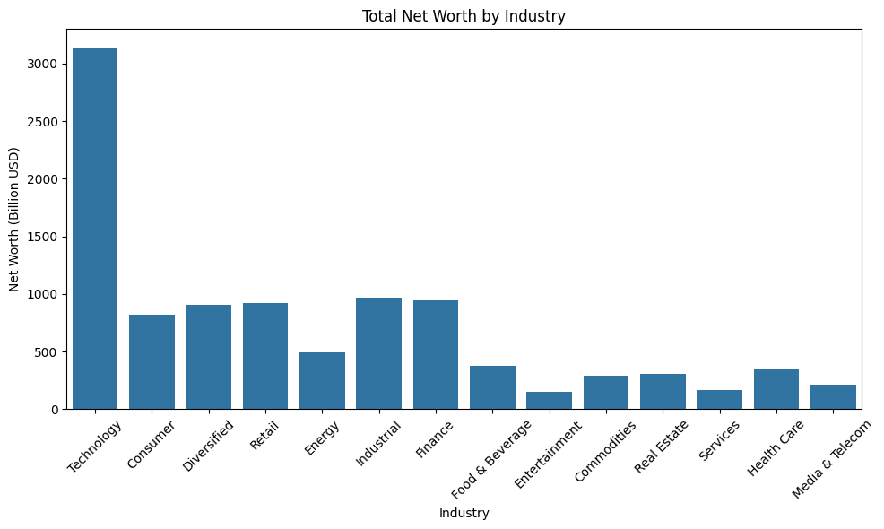

```python
plt.figure(figsize=(10, 6))
sns.barplot(data=df, x='Industry', y='Total net worth', ci=None, estimator=sum)
plt.title('Total Net Worth by Industry')
plt.xticks(rotation=45)
plt.ylabel('Net Worth (Billion USD)')
plt.xlabel('Industry')
plt.tight_layout()
plt.show()
```

2. Top 10 Individuals by Net Worth

Selects the top 10 entries with the largest net worth.

```
nlargest(10, 'Total net worth')
```

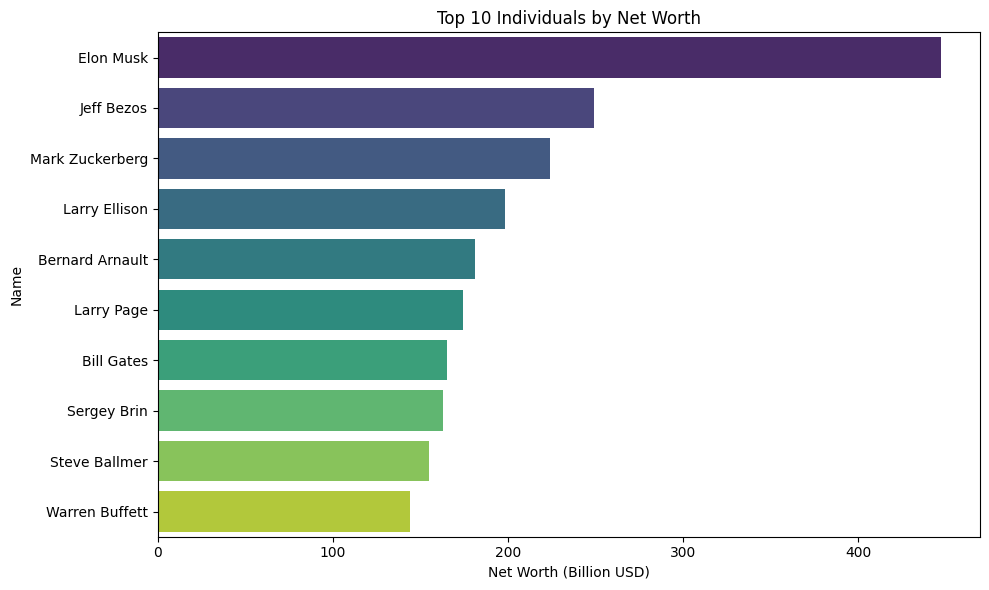

```python
top_10 = df.nlargest(10, 'Total net worth')
plt.figure(figsize=(10, 6))
sns.barplot(data=top_10, y='Name', x='Total net worth', palette='viridis')
plt.title('Top 10 Individuals by Net Worth')
plt.xlabel('Net Worth (Billion USD)')
plt.ylabel('Name')
plt.tight_layout()
plt.show()
```

3. Distribution of Net Worth by Region

   Groups the dataset by the values in the 'Country / Region' column.

   ```
    df.groupby('Country / Region')
   ```

   Sums the total net worth for each region.

   ```
    ['Total net worth'].sum()
   ```

   Sorts the resulting sums in descending order to visualize the regions with the highest total net worth first.

   ```
    .sort_values(ascending=False)
   ```

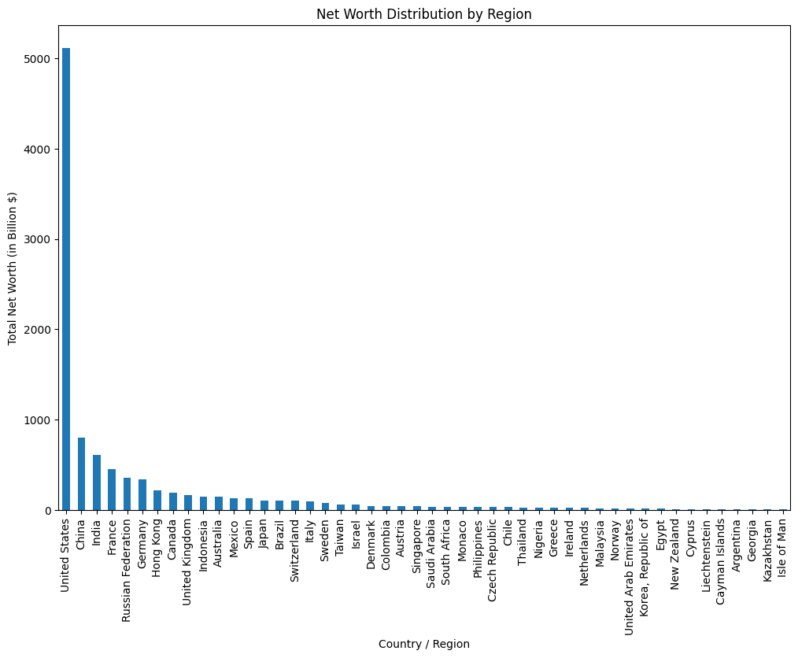

```python
region_totals = df.groupby('Country / Region')['Total net worth'].sum().sort_values(ascending=False)
region_totals.plot(kind='bar', figsize=(12, 8))
plt.title('Net Worth Distribution by Region')
plt.ylabel('Total Net Worth (in Billion $)')
plt.xlabel('Country / Region')
plt.xticks(rotation=90)
plt.show()
```

4. Calculate the average total net worth for each industry

For each industry group, we then access the 'Total net worth' column to calculate the average net worth.

```
'Total net worth']
```

This calculates the average net worth for each industry.

```
.mean()
```

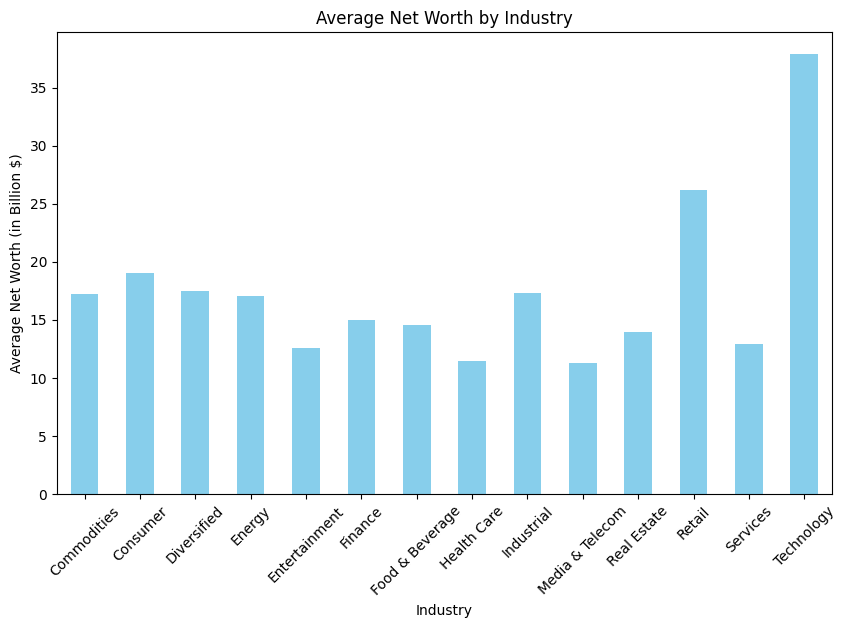

```python
industry_avg_net_worth = df.groupby('Industry')['Total net worth'].mean()
industry_avg_net_worth.plot(kind='bar', figsize=(10, 6), color='skyblue')
plt.title('Average Net Worth by Industry')
plt.ylabel('Average Net Worth (in Billion $)')
plt.xlabel('Industry')
plt.xticks(rotation=45)

plt.show()
```

5. The growth in net worth across different industries.

This function takes a value and cleans it by removing any unwanted characters (like $, B, M, or commas), and then converts it to a numeric type (float)

```
def clean_currency(value)
```

Checks if the value is a string.

```
isinstance(value, str)
```

Removes any leading or trailing whitespace from the string.

```
value.strip()
```

Checks if the string contains 'B', which represents billions.

```
'B' in value
```

Removes the dollar sign, 'B', and commas, and converts the cleaned string into a float.

```
value.replace('$', '').replace('B', '').replace(',', '')
```

Checks if the string contains 'M', representing millions, and adjusts accordingly by converting to billions (/ 1000).

```
elif 'M' in value
```

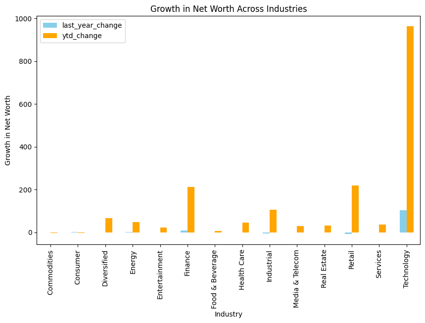

```python
def clean_currency(value):
    """Clean and convert currency values to numeric."""
    if isinstance(value, str):
        value = value.strip()
        if 'B' in value:
            return float(value.replace('$', '').replace('B', '').replace(',', ''))
        elif 'M' in value:
            return float(value.replace('$', '').replace('M', '').replace(',', '')) / 1000
    elif isinstance(value, (int, float)):
        return float(value)  # Return the number as is if it's already numeric
    return pd.NA  # Handle non-numeric values as NaN

# Step 1: Clean currency columns
df['$ Last change'] = df['$ Last change'].apply(clean_currency)
df['$ YTD change'] = df['$ YTD change'].apply(clean_currency)

# Step 2: Group by 'Industry' and calculate the total net worth and change
industry_growth = df.groupby('Industry').agg(
    total_net_worth=('Total net worth', 'sum'),
    last_year_change=('$ Last change', 'sum'),
    ytd_change=('$ YTD change', 'sum')
).dropna()  # Drop NaN values

# Step 3: Plot the results
industry_growth[['last_year_change', 'ytd_change']].plot(kind='bar', figsize=(10, 6), color=['skyblue', 'orange'])

# Adding title and labels
plt.title('Growth in Net Worth Across Industries')
plt.xlabel('Industry')
plt.ylabel('Growth in Net Worth')

plt.show()
```

6. Average YTD Change by Industry

The plot created shows the average Year-To-Date (YTD) change in net worth for each industry.

Within each grouped industry, it calculates the mean (average) of the '$ YTD change' column.

```
['$ YTD change']:
```

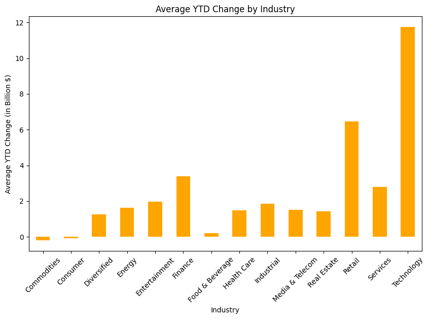

```python
industry_avg_ytd_change = df.groupby('Industry')['$ YTD change'].mean()
industry_avg_ytd_change.plot(kind='bar', figsize=(10, 6), color='orange')
plt.title('Average YTD Change by Industry')
plt.ylabel('Average YTD Change (in Billion $)')
plt.xlabel('Industry')
plt.xticks(rotation=45)

plt.show()
```

# Key Observations:

The dataset contains individuals from 48 countries across 14 industries.

The highest total net worth is $447B (Elon Musk), while the lowest is $6.38B.

The most frequent country is United States (191 entries), and the most common industry is Technology (83 entries).

# Conclusion

In this tutorial, we explored how to analyze and visualize growth in net worth across industries using Python. We started by cleaning and transforming currency values, ensuring the data was in a suitable format for analysis. We then grouped the data by industry and calculated the total net worth and changes in net worth. Finally, we created a bar plot to visualize the growth in net worth across industries, showcasing both the last year's change and the year-to-date change. This step-by-step approach helped us gain insights into how different industries have performed financially over time.